# Data Scaling

## Use of AI: can be used, but must be reported.

## AI shall not be used to complete the whole assignment.

```python
# Take the necessary libraries in use
import pandas as pd
import numpy as np
import matplotlib as mp
import matplotlib.pyplot as plt
import seaborn as sns
```

## Apartment rents data

We will use the rents of appartments as an example in this exercise

```python
# Load the data and check the shape
df = pd.read_excel("Apartment_rents.xlsx" ,sheet_name='Data')
# Check the shape of the data
df.shape
```

```
(70, 1)
```

```python
# Check how the data looks like
df.head(10)
```

|  | Rent |
| --- | --- |
| 0 | 425 |
| 1 | 430 |
| 2 | 430 |
| 3 | 435 |
| 4 | 435 |
| 5 | 435 |
| 6 | 435 |
| 7 | 435 |
| 8 | 440 |
| 9 | 440 |

```python
# Check the info of the data
df.info()
```

```
<class 'pandas.DataFrame'>
RangeIndex: 70 entries, 0 to 69
Data columns (total 1 columns):
 #   Column  Non-Null Count  Dtype
---  ------  --------------  -----
 0   Rent    70 non-null     int64
dtypes: int64(1)
memory usage: 692.0 bytes
```

```python
# Let's see the statistics
df.describe()
```

|  | Rent |
| --- | --- |
| count | 70.000000 |
| mean | 490.800000 |
| std | 54.737211 |
| min | 425.000000 |
| 25% | 446.250000 |
| 50% | 475.000000 |
| 75% | 522.500000 |
| max | 615.000000 |

```python
# Let's check the values
print("Data in groups of 10:")
print(df.iloc[0:10].transpose())
print(df.iloc[10:20].transpose())
print(df.iloc[0:10].transpose()) # <== This line seems to be a duplicate of the first print statement.
print(df.iloc[60:70].transpose())
```

```
Data in groups of 10:
        0    1    2    3    4    5    6    7    8    9
Rent  425  430  430  435  435  435  435  435  440  440
       10   11   12   13   14   15   16   17   18   19
Rent  440  440  440  445  445  445  445  445  450  450
        0    1    2    3    4    5    6    7    8    9
Rent  425  430  430  435  435  435  435  435  440  440
       60   61   62   63   64   65   66   67   68   69
Rent  575  575  580  590  600  600  600  600  615  615
```

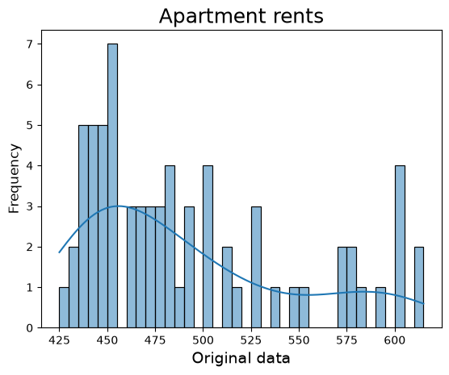

```python
# Plot data and use binwith = 5 to visualize using a histogram
sns.histplot(data=df, x='Rent', binwidth=5, kde=True)
plt.xlabel('Original data', fontsize=14)
plt.ylabel('Frequency', fontsize=12)
plt.title("Apartment rents", fontsize=18)
plt.show()
```

### Data Standardization

- Data is converted to so called z-scores, where each value z = (x - mean)/standard deviation
- This can be done using StandardScaler from the Scikit-Learn library
- fit_transform completes the conversion for the StandardScaler object

```python
# data standardization with  sklearn
from sklearn.preprocessing import StandardScaler
stdScaler = StandardScaler()
scaler = stdScaler.fit_transform(df)
# Note data is transposed to get it presented in less space in this notebook
print(scaler.transpose())
```

```
[[-1.21078686 -1.11878178 -1.11878178 -1.0267767  -1.0267767  -1.0267767
  -1.0267767  -1.0267767  -0.93477162 -0.93477162 -0.93477162 -0.93477162
  -0.93477162 -0.84276654 -0.84276654 -0.84276654 -0.84276654 -0.84276654
  -0.75076146 -0.75076146 -0.75076146 -0.75076146 -0.75076146 -0.75076146
  -0.75076146 -0.5667513  -0.5667513  -0.5667513  -0.47474622 -0.47474622
  -0.47474622 -0.38274114 -0.38274114 -0.3459391  -0.29073605 -0.29073605
  -0.29073605 -0.19873097 -0.19873097 -0.19873097 -0.19873097 -0.10672589
  -0.01472081 -0.01472081 -0.01472081  0.16928935  0.16928935  0.16928935
   0.16928935  0.35329951  0.35329951  0.44530459  0.62931475  0.62931475
   0.62931475  0.81332491  1.07093914  1.08934015  1.45736048  1.45736048
   1.54936556  1.54936556  1.64137064  1.8253808   2.00939096  2.00939096
   2.00939096  2.00939096  2.2854062   2.2854062 ]]
```

```python
# Values are
print("shape of scaler:", scaler.shape)
print("data as it is:")
scaler
```

```
shape of scaler: (70, 1)
data as it is:
```

```
array([[-1.21078686],
       [-1.11878178],
       [-1.11878178],
       [-1.0267767 ],
       [-1.0267767 ],
       [-1.0267767 ],
       [-1.0267767 ],
       [-1.0267767 ],
       [-0.93477162],
       [-0.93477162],
       [-0.93477162],
       [-0.93477162],
       [-0.93477162],
       [-0.84276654],
       [-0.84276654],
       [-0.84276654],
       [-0.84276654],
       [-0.84276654],
       [-0.75076146],
       [-0.75076146],
       [-0.75076146],
       [-0.75076146],
       [-0.75076146],
       [-0.75076146],
       [-0.75076146],
       [-0.5667513 ],
       [-0.5667513 ],
       [-0.5667513 ],
       [-0.47474622],
       [-0.47474622],
       [-0.47474622],
       [-0.38274114],
       [-0.38274114],
       [-0.3459391 ],
       [-0.29073605],
       [-0.29073605],
       [-0.29073605],
       [-0.19873097],
       [-0.19873097],
       [-0.19873097],
```

[output cut: 15 more lines]

```
       [ 0.81332491],
       [ 1.07093914],
       [ 1.08934015],
       [ 1.45736048],
       [ 1.45736048],
       [ 1.54936556],
       [ 1.54936556],
       [ 1.64137064],
       [ 1.8253808 ],
       [ 2.00939096],
       [ 2.00939096],
       [ 2.00939096],
       [ 2.00939096],
       [ 2.2854062 ],
       [ 2.2854062 ]])
```

```python
# Create Serie where standardised data is included
stand_rent = scaler[:,0]
stand_rent
```

```
array([-1.21078686, -1.11878178, -1.11878178, -1.0267767 , -1.0267767 ,
       -1.0267767 , -1.0267767 , -1.0267767 , -0.93477162, -0.93477162,
       -0.93477162, -0.93477162, -0.93477162, -0.84276654, -0.84276654,
       -0.84276654, -0.84276654, -0.84276654, -0.75076146, -0.75076146,
       -0.75076146, -0.75076146, -0.75076146, -0.75076146, -0.75076146,
       -0.5667513 , -0.5667513 , -0.5667513 , -0.47474622, -0.47474622,
       -0.47474622, -0.38274114, -0.38274114, -0.3459391 , -0.29073605,
       -0.29073605, -0.29073605, -0.19873097, -0.19873097, -0.19873097,
       -0.19873097, -0.10672589, -0.01472081, -0.01472081, -0.01472081,
        0.16928935,  0.16928935,  0.16928935,  0.16928935,  0.35329951,
        0.35329951,  0.44530459,  0.62931475,  0.62931475,  0.62931475,
        0.81332491,  1.07093914,  1.08934015,  1.45736048,  1.45736048,
        1.54936556,  1.54936556,  1.64137064,  1.8253808 ,  2.00939096,
        2.00939096,  2.00939096,  2.00939096,  2.2854062 ,  2.2854062 ])
```

#### Plot standardized data using Histogram

- Note that the data shape with histogram is different to the original data.
- Bins = 30 is used just for the example

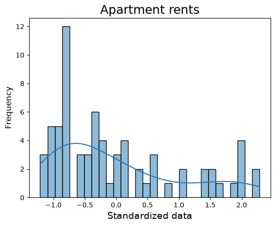

```python
# plot scaled data using histogram
sns.histplot(data = stand_rent ,bins=30, kde = True)
plt.xlabel('Standardized data', fontsize=14)
plt.ylabel('Frequency', fontsize=12)
plt.title("Apartment rents", fontsize=18)
plt.show()
```

### Data Normalization

- Data is converted linearly to values where the smallest is 0 and largest is 1, i.e. MinMax scaling
- This can be done using MinMaxScaler from the Scikit-Learn library
- fit_transform completes the conversion for the MinMaxScaler object

```python
# data normalization with sklearn
from sklearn.preprocessing import MinMaxScaler
minMaxS = MinMaxScaler()
# transform data
scaler = minMaxS.fit_transform(df)
print(scaler.transpose())
```

```
[[0.         0.02631579 0.02631579 0.05263158 0.05263158 0.05263158
  0.05263158 0.05263158 0.07894737 0.07894737 0.07894737 0.07894737
  0.07894737 0.10526316 0.10526316 0.10526316 0.10526316 0.10526316
  0.13157895 0.13157895 0.13157895 0.13157895 0.13157895 0.13157895
  0.13157895 0.18421053 0.18421053 0.18421053 0.21052632 0.21052632
  0.21052632 0.23684211 0.23684211 0.24736842 0.26315789 0.26315789
  0.26315789 0.28947368 0.28947368 0.28947368 0.28947368 0.31578947
  0.34210526 0.34210526 0.34210526 0.39473684 0.39473684 0.39473684
  0.39473684 0.44736842 0.44736842 0.47368421 0.52631579 0.52631579
  0.52631579 0.57894737 0.65263158 0.65789474 0.76315789 0.76315789
  0.78947368 0.78947368 0.81578947 0.86842105 0.92105263 0.92105263
  0.92105263 0.92105263 1.         1.        ]]
```

```python
# data as it is ...
scaler
```

```
array([[0.        ],
       [0.02631579],
       [0.02631579],
       [0.05263158],
       [0.05263158],
       [0.05263158],
       [0.05263158],
       [0.05263158],
       [0.07894737],
       [0.07894737],
       [0.07894737],
       [0.07894737],
       [0.07894737],
       [0.10526316],
       [0.10526316],
       [0.10526316],
       [0.10526316],
       [0.10526316],
       [0.13157895],
       [0.13157895],
       [0.13157895],
       [0.13157895],
       [0.13157895],
       [0.13157895],
       [0.13157895],
       [0.18421053],
       [0.18421053],
       [0.18421053],
       [0.21052632],
       [0.21052632],
       [0.21052632],
       [0.23684211],
       [0.23684211],
       [0.24736842],
       [0.26315789],
       [0.26315789],
       [0.26315789],
       [0.28947368],
       [0.28947368],
       [0.28947368],
```

[output cut: 15 more lines]

```
       [0.57894737],
       [0.65263158],
       [0.65789474],
       [0.76315789],
       [0.76315789],
       [0.78947368],
       [0.78947368],
       [0.81578947],
       [0.86842105],
       [0.92105263],
       [0.92105263],
       [0.92105263],
       [0.92105263],
       [1.        ],
       [1.        ]])
```

```python
# Create Serie where normalized data is included
norm_rent = scaler[:,0]
norm_rent
```

```
array([0.        , 0.02631579, 0.02631579, 0.05263158, 0.05263158,
       0.05263158, 0.05263158, 0.05263158, 0.07894737, 0.07894737,
       0.07894737, 0.07894737, 0.07894737, 0.10526316, 0.10526316,
       0.10526316, 0.10526316, 0.10526316, 0.13157895, 0.13157895,
       0.13157895, 0.13157895, 0.13157895, 0.13157895, 0.13157895,
       0.18421053, 0.18421053, 0.18421053, 0.21052632, 0.21052632,
       0.21052632, 0.23684211, 0.23684211, 0.24736842, 0.26315789,
       0.26315789, 0.26315789, 0.28947368, 0.28947368, 0.28947368,
       0.28947368, 0.31578947, 0.34210526, 0.34210526, 0.34210526,
       0.39473684, 0.39473684, 0.39473684, 0.39473684, 0.44736842,
       0.44736842, 0.47368421, 0.52631579, 0.52631579, 0.52631579,
       0.57894737, 0.65263158, 0.65789474, 0.76315789, 0.76315789,
       0.78947368, 0.78947368, 0.81578947, 0.86842105, 0.92105263,
       0.92105263, 0.92105263, 0.92105263, 1.        , 1.        ])
```

#### Plot normalized data using Histogram

- Note that the data shape with histogram is same to the original data.
- Bins = 40 is used just for the example

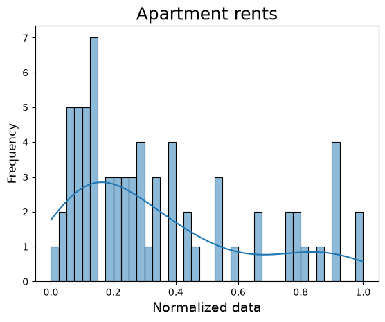

```python
# plot data
sns.histplot(data=norm_rent ,bins=40, kde=True)
plt.xlabel('Normalized data', fontsize=14)
plt.ylabel('Frequency', fontsize=12)
plt.title("Apartment rents", fontsize=18)
plt.show()
```

## Tasks, data scaling

Read the dataset 'iris' using Seaborn: sns.load_dataset( ). Check the usual information about the data (see what has been done in previous assignments or at the beginning of this one).

- Add more coding cells if necessary. Use at least 1 cell for each task (or more).
- Use data for 'sepal_length' and visualize using a histogram (like done earlier in this exercise). Decide what is a good amount of bins. Use sns.histplot with kde=true.
- Scale the data using StandardScaler, visualize scaled data using histogram. Use the same amount of bins than above. Use sns.histplot with kde=true.
- Scale the data using MinMaxScaler, visualize scaled data using histogram. Use the same amount of bins than above. Use sns.histplot with kde=true.
- Find 3rd scaler in Scikit-Learn and scale the data using it, visualize scaled data using histogram. Use the same amount of bins than above. Use sns.histplot with kde=true.
- Write a short summary, how the histograms differ from each other (if they do).

```python
# Your code here
iris = sns.load_dataset('iris')
iris.head()
```

|  | sepal_length | sepal_width | petal_length | petal_width | species |
| --- | --- | --- | --- | --- | --- |
| 0 | 5.1 | 3.5 | 1.4 | 0.2 | setosa |
| 1 | 4.9 | 3.0 | 1.4 | 0.2 | setosa |
| 2 | 4.7 | 3.2 | 1.3 | 0.2 | setosa |
| 3 | 4.6 | 3.1 | 1.5 | 0.2 | setosa |
| 4 | 5.0 | 3.6 | 1.4 | 0.2 | setosa |

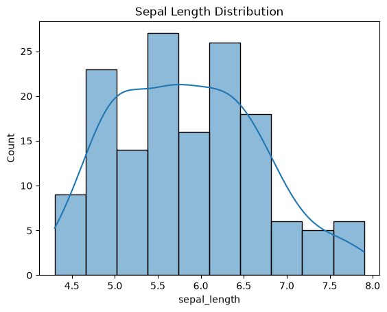

```python
sns.histplot(data=iris, x='sepal_length', bins=10, kde=True)
plt.title("Sepal Length Distribution")
```

```python
# Standardization of the data using StandardScaler
from sklearn.preprocessing import StandardScaler
stdScaler = StandardScaler()
scaled_iris = stdScaler.fit_transform(iris[['sepal_length']])
print("Standardized data:", scaled_iris.transpose())
```

```
Standardized data: [[-0.90068117 -1.14301691 -1.38535265 -1.50652052 -1.02184904 -0.53717756
  -1.50652052 -1.02184904 -1.74885626 -1.14301691 -0.53717756 -1.26418478
  -1.26418478 -1.87002413 -0.05250608 -0.17367395 -0.53717756 -0.90068117
  -0.17367395 -0.90068117 -0.53717756 -0.90068117 -1.50652052 -0.90068117
  -1.26418478 -1.02184904 -1.02184904 -0.7795133  -0.7795133  -1.38535265
  -1.26418478 -0.53717756 -0.7795133  -0.41600969 -1.14301691 -1.02184904
  -0.41600969 -1.14301691 -1.74885626 -0.90068117 -1.02184904 -1.62768839
  -1.74885626 -1.02184904 -0.90068117 -1.26418478 -0.90068117 -1.50652052
  -0.65834543 -1.02184904  1.40150837  0.67450115  1.2803405  -0.41600969
   0.79566902 -0.17367395  0.55333328 -1.14301691  0.91683689 -0.7795133
  -1.02184904  0.06866179  0.18982966  0.31099753 -0.29484182  1.03800476
  -0.29484182 -0.05250608  0.4321654  -0.29484182  0.06866179  0.31099753
   0.55333328  0.31099753  0.67450115  0.91683689  1.15917263  1.03800476
   0.18982966 -0.17367395 -0.41600969 -0.41600969 -0.05250608  0.18982966
  -0.53717756  0.18982966  1.03800476  0.55333328 -0.29484182 -0.41600969
  -0.41600969  0.31099753 -0.05250608 -1.02184904 -0.29484182 -0.17367395
  -0.17367395  0.4321654  -0.90068117 -0.17367395  0.55333328 -0.05250608
   1.52267624  0.55333328  0.79566902  2.12851559 -1.14301691  1.76501198
   1.03800476  1.64384411  0.79566902  0.67450115  1.15917263 -0.17367395
  -0.05250608  0.67450115  0.79566902  2.24968346  2.24968346  0.18982966
   1.2803405  -0.29484182  2.24968346  0.55333328  1.03800476  1.64384411
   0.4321654   0.31099753  0.67450115  1.64384411  1.88617985  2.4920192
   0.67450115  0.55333328  0.31099753  2.24968346  0.55333328  0.67450115
   0.18982966  1.2803405   1.03800476  1.2803405  -0.05250608  1.15917263
   1.03800476  1.03800476  0.55333328  0.79566902  0.4321654   0.06866179]]
```

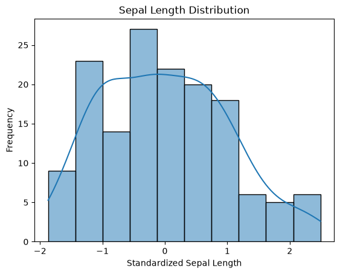

```python
sns.histplot(scaled_iris, bins=10, kde=True, legend=False)
plt.title("Sepal Length Distribution")
plt.xlabel("Standardized Sepal Length")
plt.ylabel("Frequency")
```

```python
# Normalization of the data using MinMaxScaler
from sklearn.preprocessing import MinMaxScaler
minMaxS = MinMaxScaler()
scaled_iris = minMaxS.fit_transform(iris[['sepal_length']])
print("Normalized data:", scaled_iris.transpose())
```

```
Normalized data: [[0.22222222 0.16666667 0.11111111 0.08333333 0.19444444 0.30555556
  0.08333333 0.19444444 0.02777778 0.16666667 0.30555556 0.13888889
  0.13888889 0.         0.41666667 0.38888889 0.30555556 0.22222222
  0.38888889 0.22222222 0.30555556 0.22222222 0.08333333 0.22222222
  0.13888889 0.19444444 0.19444444 0.25       0.25       0.11111111
  0.13888889 0.30555556 0.25       0.33333333 0.16666667 0.19444444
  0.33333333 0.16666667 0.02777778 0.22222222 0.19444444 0.05555556
  0.02777778 0.19444444 0.22222222 0.13888889 0.22222222 0.08333333
  0.27777778 0.19444444 0.75       0.58333333 0.72222222 0.33333333
  0.61111111 0.38888889 0.55555556 0.16666667 0.63888889 0.25
  0.19444444 0.44444444 0.47222222 0.5        0.36111111 0.66666667
  0.36111111 0.41666667 0.52777778 0.36111111 0.44444444 0.5
  0.55555556 0.5        0.58333333 0.63888889 0.69444444 0.66666667
  0.47222222 0.38888889 0.33333333 0.33333333 0.41666667 0.47222222
  0.30555556 0.47222222 0.66666667 0.55555556 0.36111111 0.33333333
  0.33333333 0.5        0.41666667 0.19444444 0.36111111 0.38888889
  0.38888889 0.52777778 0.22222222 0.38888889 0.55555556 0.41666667
  0.77777778 0.55555556 0.61111111 0.91666667 0.16666667 0.83333333
  0.66666667 0.80555556 0.61111111 0.58333333 0.69444444 0.38888889
  0.41666667 0.58333333 0.61111111 0.94444444 0.94444444 0.47222222
  0.72222222 0.36111111 0.94444444 0.55555556 0.66666667 0.80555556
  0.52777778 0.5        0.58333333 0.80555556 0.86111111 1.
  0.58333333 0.55555556 0.5        0.94444444 0.55555556 0.58333333
  0.47222222 0.72222222 0.66666667 0.72222222 0.41666667 0.69444444
  0.66666667 0.66666667 0.55555556 0.61111111 0.52777778 0.44444444]]
```

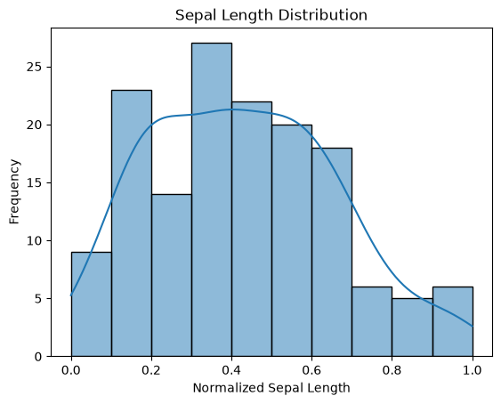

```python
sns.histplot(scaled_iris, bins=10, kde=True, legend=False)
plt.title("Sepal Length Distribution")
plt.xlabel("Normalized Sepal Length")
plt.ylabel("Frequency")
```

```python
# I used AI to learn about RobustScaler and how to use it in Python for data scaling.
# I found out that RobustScaler is better than StandardScaler because it does not contain outliers in the data.
# It is more robust to outliers than StandardScaler.
from sklearn.preprocessing import RobustScaler
robustScaler = RobustScaler()
scaled_iris = robustScaler.fit_transform(iris[['sepal_length']])
print("Robust Scaled data:", scaled_iris.transpose())
```

```
Robust Scaled data: [[-0.53846154 -0.69230769 -0.84615385 -0.92307692 -0.61538462 -0.30769231
  -0.92307692 -0.61538462 -1.07692308 -0.69230769 -0.30769231 -0.76923077
  -0.76923077 -1.15384615  0.         -0.07692308 -0.30769231 -0.53846154
  -0.07692308 -0.53846154 -0.30769231 -0.53846154 -0.92307692 -0.53846154
  -0.76923077 -0.61538462 -0.61538462 -0.46153846 -0.46153846 -0.84615385
  -0.76923077 -0.30769231 -0.46153846 -0.23076923 -0.69230769 -0.61538462
  -0.23076923 -0.69230769 -1.07692308 -0.53846154 -0.61538462 -1.
  -1.07692308 -0.61538462 -0.53846154 -0.76923077 -0.53846154 -0.92307692
  -0.38461538 -0.61538462  0.92307692  0.46153846  0.84615385 -0.23076923
   0.53846154 -0.07692308  0.38461538 -0.69230769  0.61538462 -0.46153846
  -0.61538462  0.07692308  0.15384615  0.23076923 -0.15384615  0.69230769
  -0.15384615  0.          0.30769231 -0.15384615  0.07692308  0.23076923
   0.38461538  0.23076923  0.46153846  0.61538462  0.76923077  0.69230769
   0.15384615 -0.07692308 -0.23076923 -0.23076923  0.          0.15384615
  -0.30769231  0.15384615  0.69230769  0.38461538 -0.15384615 -0.23076923
  -0.23076923  0.23076923  0.         -0.61538462 -0.15384615 -0.07692308
  -0.07692308  0.30769231 -0.53846154 -0.07692308  0.38461538  0.
   1.          0.38461538  0.53846154  1.38461538 -0.69230769  1.15384615
   0.69230769  1.07692308  0.53846154  0.46153846  0.76923077 -0.07692308
   0.          0.46153846  0.53846154  1.46153846  1.46153846  0.15384615
   0.84615385 -0.15384615  1.46153846  0.38461538  0.69230769  1.07692308
   0.30769231  0.23076923  0.46153846  1.07692308  1.23076923  1.61538462
   0.46153846  0.38461538  0.23076923  1.46153846  0.38461538  0.46153846
   0.15384615  0.84615385  0.69230769  0.84615385  0.          0.76923077
   0.69230769  0.69230769  0.38461538  0.53846154  0.30769231  0.07692308]]
```

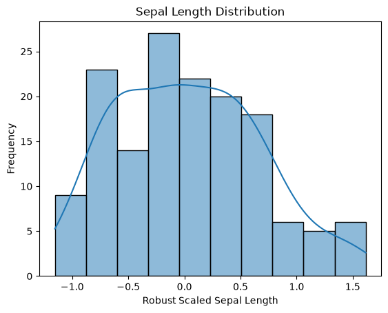

```python
# Plot with RobustScaler using seaborn
sns.histplot(scaled_iris, bins=10, kde=True, legend=False)
plt.title("Sepal Length Distribution")
plt.xlabel("Robust Scaled Sepal Length")
plt.ylabel("Frequency")
```

# My Reflections

1. StandardScaler uses the mean and standard deviation, so its values normally range from -3 to 3. Other values are treated as outliers.
2. MinMaxScaler has a range of values from 0 to 1. If the data has outliers, the whole thing will be stretched by the outliers.
3. RobustScaler uses the median and IQR (Interquartile Range, indicating the range from 25% to 75%). This is the best approach to keep the output data of the best quality.

# Regression Analysis

## Simple Linear Regression

- one independent (x) and one dependent (y) variable
- use LinearRegression from the Scikit-Learn library

```python
# Take Linear regression in use from Scikit-learn
from sklearn.linear_model import LinearRegression
# import scipy.stats as stats # library for statistical measurementssns.get_dataset_names()
```

```python
# Check names of sns datasets
sns.get_dataset_names()
```

```
['anagrams',
 'anscombe',
 'attention',
 'brain_networks',
 'car_crashes',
 'diamonds',
 'dots',
 'dowjones',
 'exercise',
 'flights',
 'fmri',
 'geyser',
 'glue',
 'healthexp',
 'iris',
 'mpg',
 'penguins',
 'planets',
 'seaice',
 'taxis',
 'tips',
 'titanic']
```

```python
# Load data
df_tips = sns.load_dataset('tips')
df_tips.head()
```

|  | total_bill | tip | sex | smoker | day | time | size |
| --- | --- | --- | --- | --- | --- | --- | --- |
| 0 | 16.99 | 1.01 | Female | No | Sun | Dinner | 2 |
| 1 | 10.34 | 1.66 | Male | No | Sun | Dinner | 3 |
| 2 | 21.01 | 3.50 | Male | No | Sun | Dinner | 3 |
| 3 | 23.68 | 3.31 | Male | No | Sun | Dinner | 2 |
| 4 | 24.59 | 3.61 | Female | No | Sun | Dinner | 4 |

```python
df_tips.info()
```

```
<class 'pandas.DataFrame'>
RangeIndex: 244 entries, 0 to 243
Data columns (total 7 columns):
 #   Column      Non-Null Count  Dtype
---  ------      --------------  -----
 0   total_bill  244 non-null    float64
 1   tip         244 non-null    float64
 2   sex         244 non-null    category
 3   smoker      244 non-null    category
 4   day         244 non-null    category
 5   time        244 non-null    category
 6   size        244 non-null    int64
dtypes: category(4), float64(2), int64(1)
memory usage: 7.4 KB
```

```python
# create vectors containing the data
# x independent variable
x = df_tips['total_bill'].values
x
```

```
array([16.99, 10.34, 21.01, 23.68, 24.59, 25.29,  8.77, 26.88, 15.04,
       14.78, 10.27, 35.26, 15.42, 18.43, 14.83, 21.58, 10.33, 16.29,
       16.97, 20.65, 17.92, 20.29, 15.77, 39.42, 19.82, 17.81, 13.37,
       12.69, 21.7 , 19.65,  9.55, 18.35, 15.06, 20.69, 17.78, 24.06,
       16.31, 16.93, 18.69, 31.27, 16.04, 17.46, 13.94,  9.68, 30.4 ,
       18.29, 22.23, 32.4 , 28.55, 18.04, 12.54, 10.29, 34.81,  9.94,
       25.56, 19.49, 38.01, 26.41, 11.24, 48.27, 20.29, 13.81, 11.02,
       18.29, 17.59, 20.08, 16.45,  3.07, 20.23, 15.01, 12.02, 17.07,
       26.86, 25.28, 14.73, 10.51, 17.92, 27.2 , 22.76, 17.29, 19.44,
       16.66, 10.07, 32.68, 15.98, 34.83, 13.03, 18.28, 24.71, 21.16,
       28.97, 22.49,  5.75, 16.32, 22.75, 40.17, 27.28, 12.03, 21.01,
       12.46, 11.35, 15.38, 44.3 , 22.42, 20.92, 15.36, 20.49, 25.21,
       18.24, 14.31, 14.  ,  7.25, 38.07, 23.95, 25.71, 17.31, 29.93,
       10.65, 12.43, 24.08, 11.69, 13.42, 14.26, 15.95, 12.48, 29.8 ,
        8.52, 14.52, 11.38, 22.82, 19.08, 20.27, 11.17, 12.26, 18.26,
        8.51, 10.33, 14.15, 16.  , 13.16, 17.47, 34.3 , 41.19, 27.05,
       16.43,  8.35, 18.64, 11.87,  9.78,  7.51, 14.07, 13.13, 17.26,
       24.55, 19.77, 29.85, 48.17, 25.  , 13.39, 16.49, 21.5 , 12.66,
       16.21, 13.81, 17.51, 24.52, 20.76, 31.71, 10.59, 10.63, 50.81,
       15.81,  7.25, 31.85, 16.82, 32.9 , 17.89, 14.48,  9.6 , 34.63,
       34.65, 23.33, 45.35, 23.17, 40.55, 20.69, 20.9 , 30.46, 18.15,
       23.1 , 15.69, 19.81, 28.44, 15.48, 16.58,  7.56, 10.34, 43.11,
       13.  , 13.51, 18.71, 12.74, 13.  , 16.4 , 20.53, 16.47, 26.59,
       38.73, 24.27, 12.76, 30.06, 25.89, 48.33, 13.27, 28.17, 12.9 ,
       28.15, 11.59,  7.74, 30.14, 12.16, 13.42,  8.58, 15.98, 13.42,
       16.27, 10.09, 20.45, 13.28, 22.12, 24.01, 15.69, 11.61, 10.77,
       15.53, 10.07, 12.6 , 32.83, 35.83, 29.03, 27.18, 22.67, 17.82,
       18.78])
```

```python
x.shape
```

```
(244,)
```

```python
# Create vector x containing the data 'total_bill' as 1-dimensional ndarray
x = df_tips['total_bill'].values.reshape(-1,1)
print("shape:", x.shape)
# show 10 first items of the array x
print("first 10 values of x:", x [0:10])
```

```
shape: (244, 1)
first 10 values of x: [[16.99]
 [10.34]
 [21.01]
 [23.68]
 [24.59]
 [25.29]
 [ 8.77]
 [26.88]
 [15.04]
 [14.78]]
```

```python
# Show the last 10 values of the array x using slicing
print("last 10 values of x:", x [-10:])
```

```
last 10 values of x: [[15.53]
 [10.07]
 [12.6 ]
 [32.83]
 [35.83]
 [29.03]
 [27.18]
 [22.67]
 [17.82]
 [18.78]]
```

```python
# create vector y containing the data 'tip'
y = df_tips['tip'].values
# show 20 first items of the array y
y [0:20]
```

```
array([1.01, 1.66, 3.5 , 3.31, 3.61, 4.71, 2.  , 3.12, 1.96, 3.23, 1.71,
       5.  , 1.57, 3.  , 3.02, 3.92, 1.67, 3.71, 3.5 , 3.35])
```

```python
# Create linear regression model
model = LinearRegression()
# fit the data
model.fit(x, y)
# calculate the coefficients
slope = model.coef_[0]
intercept = model.intercept_
print(f"Slope: {slope}")
print(f"Intercept: {intercept}")
```

```
Slope: 0.10502451738435337
Intercept: 0.9202696135546731
```

## Visualise the results using a scatter plot

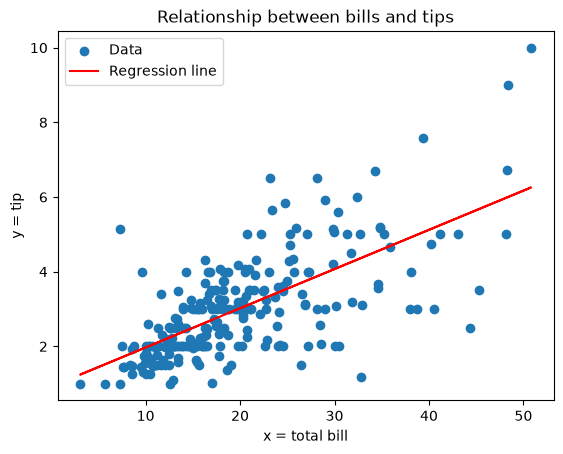

```python
# Visualise the results
# show the scatter diagram for the data and the linear regression line
plt.scatter(x, y, label='Data')
plt.plot(x, model.predict(x), color='red', label='Regression line')
plt.xlabel('x = total bill')
plt.ylabel('y = tip')
plt.title('Relationship between bills and tips')
plt.legend()
plt.show()
```

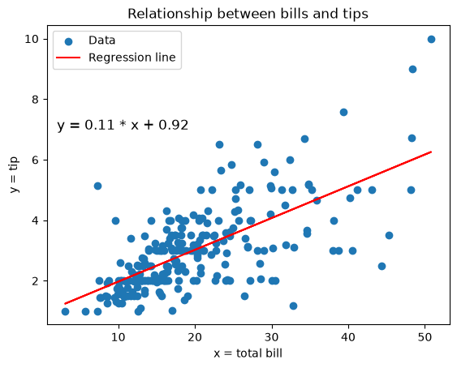

```python
# Add the equation formula as a text annotation to the plot
plt.scatter(x, y, label='Data')
plt.plot(x, model.predict(x), color='red', label='Regression line')
# Add the equation formula as a text annotation to the plot
equation_text = f'y = {slope:.2f} * x + {intercept:.2f}'
plt.text(2, 7, equation_text, fontsize=12, color='black')
plt.xlabel('x = total bill')
plt.ylabel('y = tip')
plt.title('Relationship between bills and tips')
plt.legend()
plt.show()
```

### Note: Figure could have been created also with Seaborn lmplot

- lmplot uses orginal data from DataFrame and adds the regression line

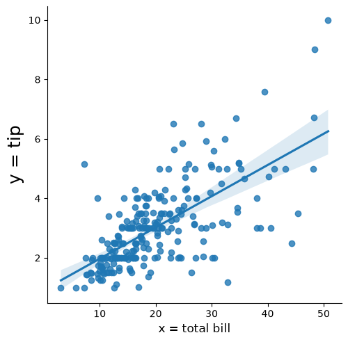

```python
# Two quantitative variables, one in x and another in y
sns.lmplot(data = df_tips, x= 'total_bill', y= 'tip')
plt.xlabel('x = total bill', fontsize=12)
plt.ylabel('y = tip', fontsize=18)
plt.show()
```

### NICE TO KNOW INFORMATION: Intercept and coefficient can be also found using library statsmodel

```python
# use statsmodel instead
import statsmodels.api as sm
from statsmodels.formula.api import ols
model = ols('tip ~ total_bill', data=df_tips).fit()
print (model.summary())
```

```
                            OLS Regression Results
==============================================================================
Dep. Variable:                    tip   R-squared:                       0.457
Model:                            OLS   Adj. R-squared:                  0.454
Method:                 Least Squares   F-statistic:                     203.4
Date:                Tue, 20 Oct 2026   Prob (F-statistic):           6.69e-34
Time:                        18:30:16   Log-Likelihood:                -350.54
No. Observations:                 244   AIC:                             705.1
Df Residuals:                     242   BIC:                             712.1
Df Model:                           1
Covariance Type:            nonrobust
==============================================================================
                 coef    std err          t      P>|t|      [0.025      0.975]
------------------------------------------------------------------------------
Intercept      0.9203      0.160      5.761      0.000       0.606       1.235
total_bill     0.1050      0.007     14.260      0.000       0.091       0.120
==============================================================================
Omnibus:                       20.185   Durbin-Watson:                   2.151
Prob(Omnibus):                  0.000   Jarque-Bera (JB):               37.750
Skew:                           0.443   Prob(JB):                     6.35e-09
Kurtosis:                       4.711   Cond. No.                         53.0
==============================================================================

Notes:
[1] Standard Errors assume that the covariance matrix of the errors is correctly specified.
```

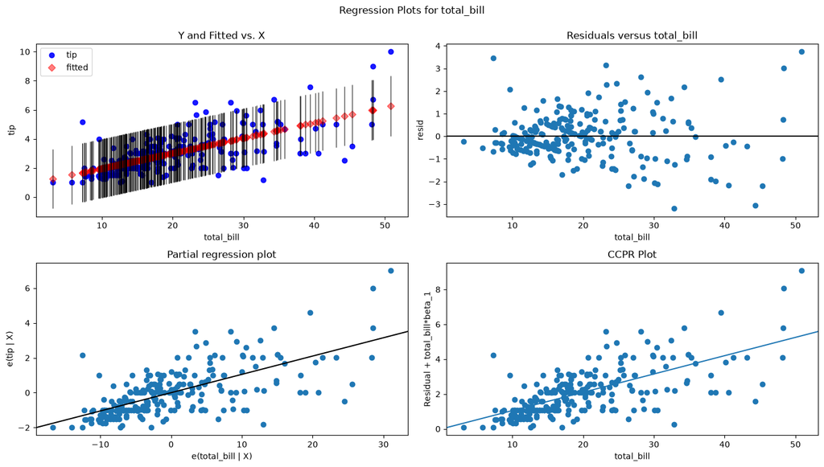

```python
# Create figures using statsmodel
fig = plt.figure(figsize=(14, 8))
fig = sm.graphics.plot_regress_exog(model,'total_bill', fig = fig)
plt.show()
```

## Multiple linear regression

- more than one independent variable (X) and one dependent (y) variable
- use LinearRegression from the Scikit-Learn library

```python
# Load data
df_diamonds = sns.load_dataset('diamonds')
df_diamonds.head()
```

|  | carat | cut | color | clarity | depth | table | price | x | y | z |
| --- | --- | --- | --- | --- | --- | --- | --- | --- | --- | --- |
| 0 | 0.23 | Ideal | E | SI2 | 61.5 | 55.0 | 326 | 3.95 | 3.98 | 2.43 |
| 1 | 0.21 | Premium | E | SI1 | 59.8 | 61.0 | 326 | 3.89 | 3.84 | 2.31 |
| 2 | 0.23 | Good | E | VS1 | 56.9 | 65.0 | 327 | 4.05 | 4.07 | 2.31 |
| 3 | 0.29 | Premium | I | VS2 | 62.4 | 58.0 | 334 | 4.20 | 4.23 | 2.63 |
| 4 | 0.31 | Good | J | SI2 | 63.3 | 58.0 | 335 | 4.34 | 4.35 | 2.75 |

```python
df_diamonds.info()
```

```
<class 'pandas.DataFrame'>
RangeIndex: 53940 entries, 0 to 53939
Data columns (total 10 columns):
 #   Column   Non-Null Count  Dtype
---  ------   --------------  -----
 0   carat    53940 non-null  float64
 1   cut      53940 non-null  category
 2   color    53940 non-null  category
 3   clarity  53940 non-null  category
 4   depth    53940 non-null  float64
 5   table    53940 non-null  float64
 6   price    53940 non-null  int64
 7   x        53940 non-null  float64
 8   y        53940 non-null  float64
 9   z        53940 non-null  float64
dtypes: category(3), float64(6), int64(1)
memory usage: 3.0 MB
```

```python
df_diamonds.shape
```

```
(53940, 10)
```

```python
# Reduce the size of the data (just for the sake of this example, usually
# reducing the data shall not be done without carefull consideration why and how
# to do it, but let's leave that out of scope of this course now.)
df1 = df_diamonds.loc [0:10000, 'carat':'price']
df1.shape
```

```
(10001, 7)
```

```python
df1.columns
```

```
Index(['carat', 'cut', 'color', 'clarity', 'depth', 'table', 'price'], dtype='str')
```

```python
# use carat and depth as independent variables store them in matrix X
# use price as dependent variable y
X = df1[['carat', 'depth']]
y = df1['price']
```

```python
model = LinearRegression()
model.fit(X, y)

coefficients = model.coef_
intercept = model.intercept_

print("Coefficients:", coefficients)
print("Intercept:", intercept)
```

```
Coefficients: [4143.69408078  -25.76813825]
Intercept: 1497.255432080341
```

### Visualise the results in 3D Scatter Diagram

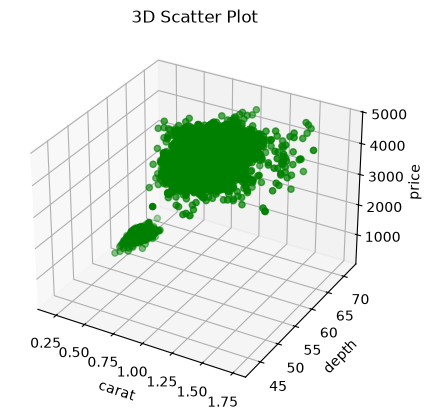

```python
# Visualise the results in 3D
from mpl_toolkits.mplot3d import Axes3D
fig = plt.figure()
ax = fig.add_subplot(111, projection='3d')
x1 = df1['carat']
x2 = df1['depth']
y = df1['price']
ax.scatter(x1, x2, y, c='green', marker='o')
ax.set_xlabel('carat')
ax.set_ylabel('depth')
ax.set_zlabel('price')
plt.title('3D Scatter Plot')
plt.show()
```

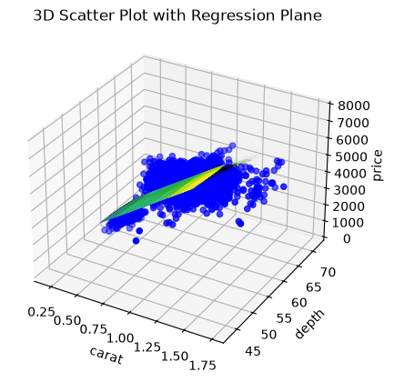

```python
# Add the regression plane in the figure
# Extract the coefficients
coef_X1, coef_X2 = model.coef_
intercept = model.intercept_
# create the figure
fig = plt.figure()
ax = fig.add_subplot(111, projection='3d')
x1 = df1['carat']
x2 = df1['depth']
y = df1['price']
# Create a meshgrid for the plane
x1_plane, x2_plane = np.meshgrid(x1, x2)
y_plane = intercept + coef_X1 * x1_plane + coef_X2 * x2_plane
ax.scatter(x1, x2, y, c='blue', marker='o', label='Data Points')
# plot the regression plane
ax.plot_surface(x1_plane, x2_plane, y_plane, alpha=0.5,
                cmap='viridis', label='Regression Plane')
ax.set_xlabel('carat')
ax.set_ylabel('depth')
ax.set_zlabel('price')
plt.title('3D Scatter Plot with Regression Plane')
plt.show()
```

### Tasks, simple linear regression

Use Seaborn dataset for 'penguins'

- Check the basic info of the dataset.
- Drop rows having missing values and check the basic info (e.g. info()-function) to verify, that NaNs were dropped.
- Find simple linear reqression between bill (x) and flipper lenghts (y).
- Print slope and intercept.
- Create a figure (use lmplot) with the equation.

```python
# Your code here
penguins = sns.load_dataset('penguins')
penguins.info()
```

```
<class 'pandas.DataFrame'>
RangeIndex: 344 entries, 0 to 343
Data columns (total 7 columns):
 #   Column             Non-Null Count  Dtype
---  ------             --------------  -----
 0   species            344 non-null    str
 1   island             344 non-null    str
 2   bill_length_mm     342 non-null    float64
 3   bill_depth_mm      342 non-null    float64
 4   flipper_length_mm  342 non-null    float64
 5   body_mass_g        342 non-null    float64
 6   sex                333 non-null    str
dtypes: float64(4), str(3)
memory usage: 18.9 KB
```

```python
penguins.dropna(inplace=True)
penguins.info()
```

```
<class 'pandas.DataFrame'>
Index: 333 entries, 0 to 343
Data columns (total 7 columns):
 #   Column             Non-Null Count  Dtype
---  ------             --------------  -----
 0   species            333 non-null    str
 1   island             333 non-null    str
 2   bill_length_mm     333 non-null    float64
 3   bill_depth_mm      333 non-null    float64
 4   flipper_length_mm  333 non-null    float64
 5   body_mass_g        333 non-null    float64
 6   sex                333 non-null    str
dtypes: float64(4), str(3)
memory usage: 20.8 KB
```

```python
penguins
```

|  | species | island | bill_length_mm | bill_depth_mm | flipper_length_mm | body_mass_g | sex |
| --- | --- | --- | --- | --- | --- | --- | --- |
| 0 | Adelie | Torgersen | 39.1 | 18.7 | 181.0 | 3750.0 | Male |
| 1 | Adelie | Torgersen | 39.5 | 17.4 | 186.0 | 3800.0 | Female |
| 2 | Adelie | Torgersen | 40.3 | 18.0 | 195.0 | 3250.0 | Female |
| 4 | Adelie | Torgersen | 36.7 | 19.3 | 193.0 | 3450.0 | Female |
| 5 | Adelie | Torgersen | 39.3 | 20.6 | 190.0 | 3650.0 | Male |
| ... | ... | ... | ... | ... | ... | ... | ... |
| 338 | Gentoo | Biscoe | 47.2 | 13.7 | 214.0 | 4925.0 | Female |
| 340 | Gentoo | Biscoe | 46.8 | 14.3 | 215.0 | 4850.0 | Female |
| 341 | Gentoo | Biscoe | 50.4 | 15.7 | 222.0 | 5750.0 | Male |
| 342 | Gentoo | Biscoe | 45.2 | 14.8 | 212.0 | 5200.0 | Female |
| 343 | Gentoo | Biscoe | 49.9 | 16.1 | 213.0 | 5400.0 | Male |

333 rows × 7 columns

```python
# I will use LinearRegression to fit the data and visualize the results, for variable bill_length_mm
# We can use 3D mode with 2 X params bill_length_mm and bill_depth_mm, but it is too complecated and I don't want here.
model = LinearRegression()
X = penguins[['bill_length_mm']]
y = penguins['flipper_length_mm']
model.fit(X, y)
```

```
LinearRegression()
```

```python
# Find slope and intercept
slope = model.coef_
intercept = model.intercept_
print(f"Slope: {slope}")
print(f"Intercept: {intercept}")
```

```
Slope: [1.67383257]
Intercept: 127.33039757802362
```

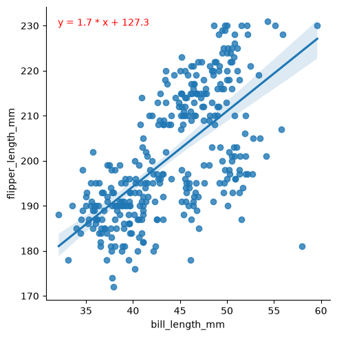

```python
g = sns.lmplot(data=penguins, x='bill_length_mm', y='flipper_length_mm')
g.ax.text(32, 230, f"y = {model.coef_[0]:.1f} * x + {model.intercept_:.1f}", fontsize=10, color='red')
plt.show()
```